# Project

Yiyi Yuan

0. Describe the data and your research question. Where does it come from? How was it collected? What do you hope to learn?
1. athlete_events.csv

The file athlete_events.csv contains 271116 rows and 15 columns;

Each row corresponds to an individual athlete competing in an individual Olympic event (athlete-events). The columns are the following:

ID - Unique number for each athlete; Name - Athlete’s name; Sex - M or F; Age - Integer; Height - In centimeters; Weight - In kilograms; Team - Team name; NOC - National Olympic Committee 3-letter code; Games - Year and season; Year - Integer; Season - Summer or Winter; City - Host city; Sport - Sport; Event - Event; Medal - Gold, Silver, Bronze, or NA.

2. noc_regions.csv

NOC; region; notes;

This dataset provides an opportunity to ask questions about how the Olympics have evolved over time

Our research question is well, we have not decided yet but soon I believe… I (Yiyi) suggest to research on how the Olympics, in all aspects, have evolved over time. For example, how does the participation and performance of women of different sports and event changed over decades, the ranks and overall performance of different nations, etc.

*Art Competitions From 1912 to 1948*

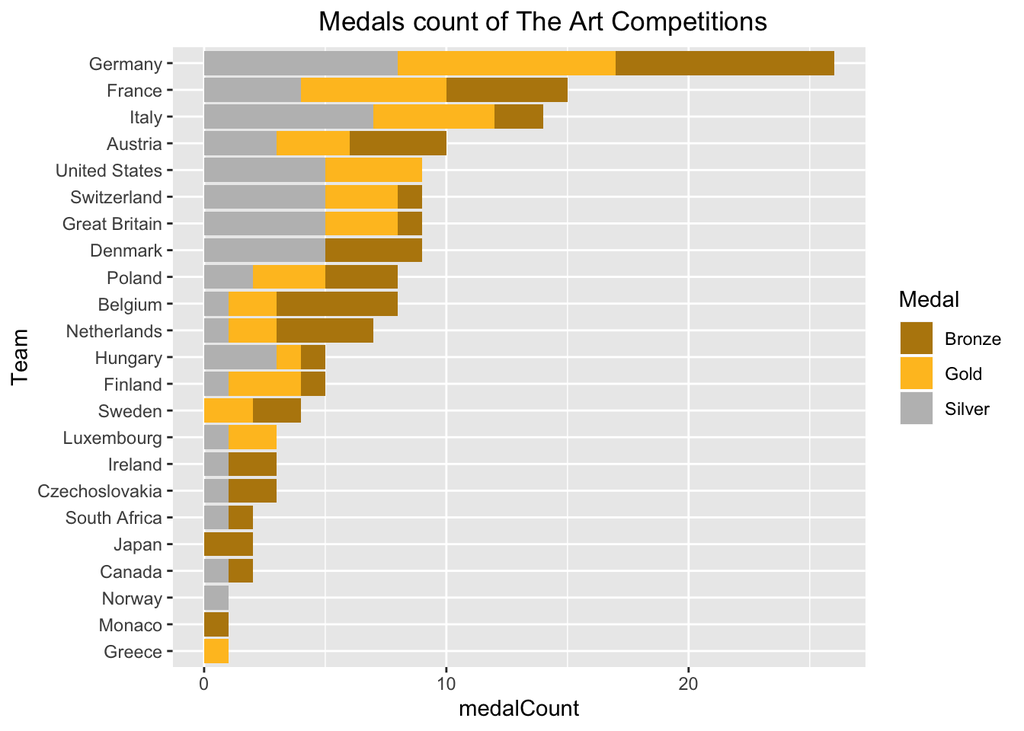

Among 50 nations, Germany won the most medals in the Art Competitions (between 1912 and 1948) Over 1/3 of medals were awarded to artists from Germany, France, Italy, and Austria.

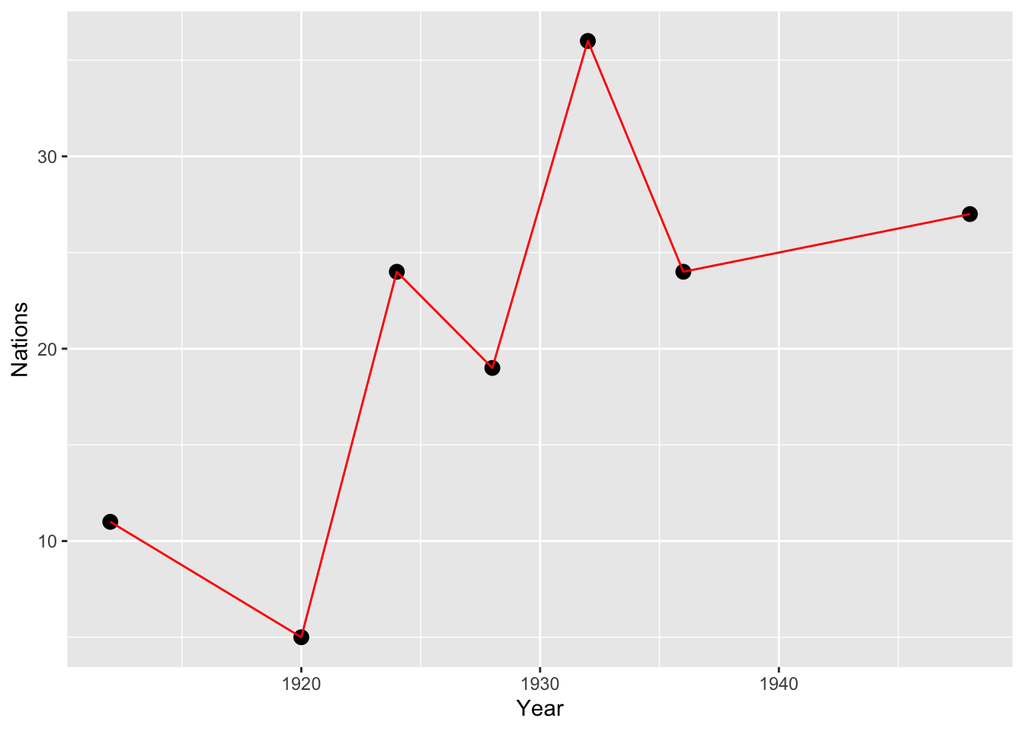

```r
# https://rpubs.com/dgrtwo/length_unique_vs_n_distinct
artTeam <- artCompetitorData %>% filter(Team != "Unknown") %>%
  group_by(Year) %>%
 summarize(
    Events = n_distinct(Event),
    Nations = n_distinct(Team),
    Artists = n_distinct(unique(Name))
  )

ggplot(artTeam, aes(x = Year, y = Nations)) +
  geom_point(size = 3) +
  geom_line(color = "red") +
  xlab("Year")
```

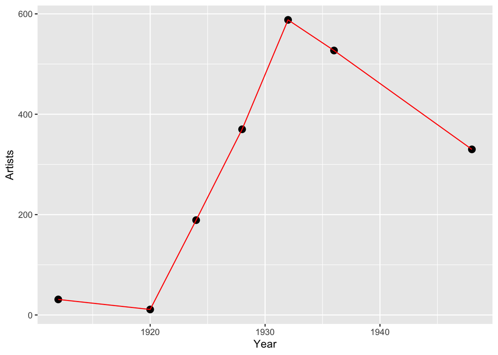

```r
ggplot(artTeam, aes(x = Year, y = Artists)) +
  geom_point(size = 3) +
  geom_line(color = "red") +
  xlab("Year")
```

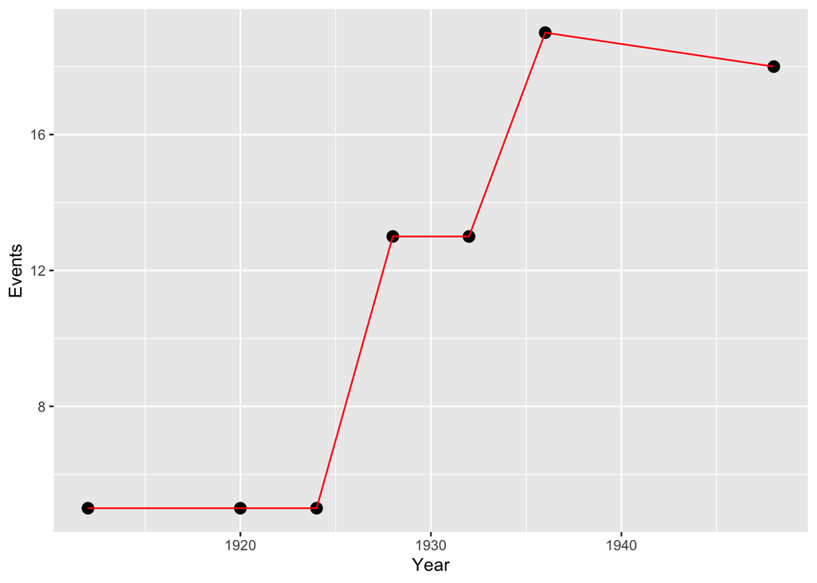

```r
ggplot(artTeam, aes(x = Year, y = Events)) +
  geom_point(size = 3) +
  geom_line(color = "red") +
  xlab("Year")
```

Apparently, nations participated, and events held increased and then decreased over time. Nations participated and artists grew hugely from 1920 to 1932, with the events that was held during that period of time boosted correspondingly.